```python
%matplotlib inline
import matplotlib
import seaborn as sns
matplotlib.rcParams['savefig.dpi'] = 2 * matplotlib.rcParams['savefig.dpi']
```

The first goal of this project is to simplify the search for new recipes from the website www.bigoven.com based on users' input so that users can save time from clicking the link to see if there's any picture provided and from reading the ingredient lists of each recipe to eliminate the ones that they obviously are not interested in. In order to achieve it, I will need to rely on stemming and converting texts into bags of words in order to have a more accurate filter.

The second goal of this project is to figure out what types of ingredients that seem to work well with what type of dishes. For example, it would be interesting to know that for example, ginger seems to always work well with chicken and vinegar seems to be never used with chicken. The results can be cross-check with popular recipes from well-known chefs from Food Network or any other TV channels.

The last goal of this project is to figure out the type of the dish that we would be able to make decently given a certain set of ingredients based on clustering and supervised learning. For example, if I already have pepper, beef, ginger, what type of dish that I should really make.

[figure not shown]

```python
from IPython.display import Image
Image(filename='Images_1/Big_oven_1.png')
```

For example, if I want to search for Italian chicken on BigOven.com, the results that I receive will provide a bunch of recipes that do not have any ratings, do not have any pictures or worse, have some types of ingredients that I do not want to eat. Therefore, I think it is useful if I can somewhat simplify my search so that I do not need to go through all of the links to figure out which recipe I should definitely ignore.

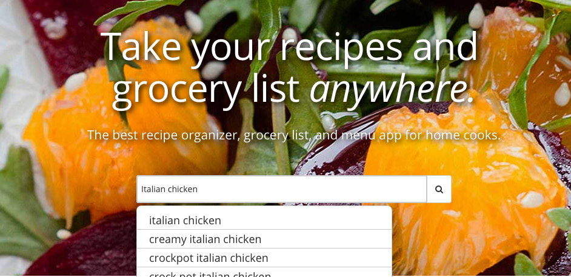

```python
from IPython.display import Image
Image(filename='Images_1/Big_oven_2.png')
```

[figure not shown]

```python
from IPython.display import Image
Image(filename='Images_1/Big_oven_3.png')
```

If I perform web scraping from the API data that the website Big Oven provides, I can basically extract out the basic information for each search such as Recipe ID, Recipe Cuisine, Recipe Title, Recipe Image Url, Recipe Rating. Using the Recipe ID, I once again can perform web scraping to extract out the information of the ingredient lists, the total minutes that I need to prepare the dish.

```python
f=open("search_df","r")
search_df=dill.load(f)
f.close()
search_df.rename(columns={'ReciptTitle': 'RecipeTitle'}, inplace=True)
#search_df
search_df[['RecipeID','RecipeTitle', 'RecipeCuisine', 'RecipeRating','RecipeUrl']]
```

|  | RecipeID | RecipeTitle | RecipeCuisine | RecipeRating | RecipeUrl |
| --- | --- | --- | --- | --- | --- |
| 0 | 345615 | Italian Chicken |  | 4.000000 | http://redirect.bigoven.com/pics/italian-chick... |
| 1 | 864092 | Italian Chicken | Italian | 0.000000 | http://redirect.bigoven.com/pics/recipe-no-ima... |
| 2 | 326895 | Italian Chicken |  | 0.000000 | http://redirect.bigoven.com/pics/recipe-no-ima... |
| 3 | 401002 | Italian chicken | Italian | 0.000000 | http://redirect.bigoven.com/pics/recipe-no-ima... |
| 4 | 721232 | Italian Chicken |  | 0.000000 | http://redirect.bigoven.com/pics/recipe-no-ima... |
| 5 | 224492 | Italian Chicken | Italian | 0.000000 | http://redirect.bigoven.com/pics/recipe-no-ima... |
| 6 | 409862 | Italian Chicken | American | 0.000000 | http://redirect.bigoven.com/pics/recipe-no-ima... |
| 7 | 358672 | Italian Chicken |  | 0.000000 | http://redirect.bigoven.com/pics/recipe-no-ima... |
| 8 | 403107 | Italian Chicken |  | 0.000000 | http://redirect.bigoven.com/pics/recipe-no-ima... |
| 9 | 739594 | Italian chicken |  | 0.000000 | http://redirect.bigoven.com/pics/recipe-no-ima... |
| 10 | 327406 | Italian Chicken |  | 0.000000 | http://redirect.bigoven.com/pics/recipe-no-ima... |
| 11 | 335463 | Italian Chicken | Italian | 0.000000 | http://redirect.bigoven.com/pics/recipe-no-ima... |
| 12 | 275330 | Italian Chicken |  | 0.000000 | http://redirect.bigoven.com/pics/recipe-no-ima... |
| 13 | 1081816 | Italian Chicken |  | 0.000000 | http://redirect.bigoven.com/pics/recipe-no-ima... |
| 14 | 101139 | Italian Chicken | American | 0.000000 | http://redirect.bigoven.com/pics/recipe-no-ima... |
| 15 | 417113 | Italian Chicken | Italian | 0.000000 | http://redirect.bigoven.com/pics/recipe-no-ima... |
| 16 | 720155 | Italian Chicken |  | 0.000000 | http://redirect.bigoven.com/pics/recipe-no-ima... |
| 17 | 366832 | Italian Chicken | Italian | 0.000000 | http://redirect.bigoven.com/pics/recipe-no-ima... |
| 18 | 411411 | Italian Chicken |  | 0.000000 | http://redirect.bigoven.com/pics/recipe-no-ima... |
| 19 | 1212088 | Italian Chicken | Italian | 0.000000 | http://redirect.bigoven.com/pics/recipe-no-ima... |
| 20 | 236087 | Italian Chicken | American | 0.000000 | http://redirect.bigoven.com/pics/recipe-no-ima... |
| 21 | 158257 | Italian Chicken | Italian | 4.750000 | http://redirect.bigoven.com/pics/italian-chick... |
| 22 | 193135 | Italian Chicken and Vegetable Pasta | Italian | 4.500000 | http://redirect.bigoven.com/pics/italian-chick... |
| 23 | 560505 | Crockpot Italian Chicken | Italian | 5.000000 | http://redirect.bigoven.com/pics/crockpot-ital... |
| 24 | 159868 | Italian Chicken Stew | American | 4.285714 | http://redirect.bigoven.com/pics/italian-chick... |
| 25 | 158319 | Italian Chicken and Green Olives | Italian | 3.857143 | http://redirect.bigoven.com/pics/italian-chick... |
| 26 | 75941 | Crockpot Italian Chicken | American | 3.600000 | http://redirect.bigoven.com/pics/crockpot-ital... |
| 27 | 1161831 | Italian Chicken Soup |  | 0.000000 | http://redirect.bigoven.com/pics/italianchicke... |
| 28 | 101537 | Italian- Chicken Cacciatore (Contadina) | American | 0.000000 | http://redirect.bigoven.com/pics/italian-chick... |
| 29 | 1264767 | Simple Crockpot Italian Chicken |  | 0.000000 | http://photos.bigoven.com/recipe/hero/simple-c... |
| ... | ... | ... | ... | ... | ... |
| 353 | 101446 | Italian Style Chicken Patties | American | 0.000000 | http://redirect.bigoven.com/pics/recipe-no-ima... |
| 354 | 664123 | Creamy Chicken Italian-O |  | 0.000000 | http://redirect.bigoven.com/pics/recipe-no-ima... |
| 355 | 311739 | Italian Sausage Stuffed Chicken | Italian | 0.000000 | http://redirect.bigoven.com/pics/recipe-no-ima... |
| 356 | 148263 | Chicken Kiev Italian Style | American | 0.000000 | http://redirect.bigoven.com/pics/recipe-no-ima... |
| 357 | 455149 | Italian Pasta with Chicken |  | 0.000000 | http://redirect.bigoven.com/pics/recipe-no-ima... |
| 358 | 218443 | Chicken, Helen's Italian Grilled | Italian | 4.000000 | http://redirect.bigoven.com/pics/recipe-no-ima... |
| 359 | 139340 | Italian Breast of Chicken | American | 0.000000 | http://redirect.bigoven.com/pics/recipe-no-ima... |
| 360 | 1165508 | Grilled Stuffed Chicken Italiano |  | 0.000000 | http://redirect.bigoven.com/pics/grilledstuffe... |
| 361 | 158656 | Chicken Italiano | Italian | 3.000000 | http://redirect.bigoven.com/pics/chicken-itali... |
| 362 | 848011 | Creamy Chicken Italiano |  | 0.000000 | http://redirect.bigoven.com/pics/recipe-no-ima... |
| 363 | 275781 | Creamy Chicken Italiano | Italian | 0.000000 | http://redirect.bigoven.com/pics/recipe-no-ima... |
| 364 | 279967 | Chicken Italiano | Italian | 0.000000 | http://redirect.bigoven.com/pics/recipe-no-ima... |
| 365 | 307654 | CHICKEN-ROTINI STIR FRY "ITALIANO" | Italian | 0.000000 | http://redirect.bigoven.com/pics/recipe-no-ima... |
| 366 | 148255 | Chicken Italiano | American | 0.000000 | http://redirect.bigoven.com/pics/recipe-no-ima... |
| 367 | 376687 | Chicken Strips Italiano | Italian | 0.000000 | http://redirect.bigoven.com/pics/recipe-no-ima... |
| 368 | 638761 | Smothered Chicken Italiano |  | 0.000000 | http://redirect.bigoven.com/pics/recipe-no-ima... |
| 369 | 240732 | Chicken Italiano |  | 0.000000 | http://redirect.bigoven.com/pics/recipe-no-ima... |
| 370 | 237875 | Simple Chicken Italiano |  | 0.000000 | http://redirect.bigoven.com/pics/recipe-no-ima... |
| 371 | 60173 | Chicken And/or Shrimp a la Italiano | American | 0.000000 | http://redirect.bigoven.com/pics/recipe-no-ima... |
| 372 | 61949 | Chicken Italiano | American | 0.000000 | http://redirect.bigoven.com/pics/recipe-no-ima... |
| 373 | 428119 | Pesto Chicken Italiano |  | 0.000000 | http://redirect.bigoven.com/pics/recipe-no-ima... |
| 374 | 108406 | Mainated Chicken Italiano | American | 0.000000 | http://redirect.bigoven.com/pics/recipe-no-ima... |
| 375 | 55760 | Simple Chicken Italiano | American | 0.000000 | http://redirect.bigoven.com/pics/recipe-no-ima... |
| 376 | 201648 | Slow Cooker Creamy Chicken Italiano | American | 0.000000 | http://redirect.bigoven.com/pics/recipe-no-ima... |
| 377 | 1120847 | Chicken Italiano |  | 0.000000 | http://redirect.bigoven.com/pics/recipe-no-ima... |
| 378 | 533808 | Chicken Italiano |  | 0.000000 | http://redirect.bigoven.com/pics/recipe-no-ima... |
| 379 | 337089 | Nana Chicken Italiano |  | 0.000000 | http://redirect.bigoven.com/pics/recipe-no-ima... |
| 380 | 62279 | Chicken Pasta Italiana | American | 0.000000 | http://redirect.bigoven.com/pics/recipe-no-ima... |
| 381 | 93899 | Grilled Chicken Italiano | American | 0.000000 | http://redirect.bigoven.com/pics/recipe-no-ima... |
| 382 | 1239900 | Chicken Pasta Salad Italiano |  | 0.000000 | http://redirect.bigoven.com/pics/recipe-no-ima... |

383 rows × 5 columns

```python
Based on the recipe ID, we can extracting out the ingredient list for each recipe according to our search.
```

```python
#Extract the
f=open("ingredients_name_all_100","r")
ingredients_name_all_100=dill.load(f)
f.close()

f=open("ingredients_name_all_200","r")
ingredients_name_all_200=dill.load(f)
f.close()

f=open("ingredients_name_all_300","r")
ingredients_name_all_300=dill.load(f)
f.close()

f=open("ingredients_name_all_383","r")
ingredients_name_all_383=dill.load(f)
f.close()


ingredients_name=ingredients_name_all_100+ ingredients_name_all_200 + \
                ingredients_name_all_300 + ingredients_name_all_383


search_df['Ingredients']=ingredients_name
for i in xrange(0, search_df.shape[0]):
    search_df['Ingredients'].values[i]=[x.lower() for x in search_df['Ingredients'].values[i]]
```

```python
search_df[['RecipeID','RecipeTitle', 'RecipeCuisine', 'RecipeRating','Ingredients', 'RecipeUrl']]
```

|  | RecipeID | RecipeTitle | RecipeCuisine | RecipeRating | Ingredients | RecipeUrl |
| --- | --- | --- | --- | --- | --- | --- |
| 0 | 345615 | Italian Chicken |  | 4.000000 | [Chicken breasts boneless and skinless, Italia... | http://redirect.bigoven.com/pics/italian-chick... |
| 1 | 864092 | Italian Chicken | Italian | 0.000000 | [cream of mushroom soup, cream cheese, dry ita... | http://redirect.bigoven.com/pics/recipe-no-ima... |
| 2 | 326895 | Italian Chicken |  | 0.000000 | [Chicken breast, Baby new potatoes, Green Bean... | http://redirect.bigoven.com/pics/recipe-no-ima... |
| 3 | 401002 | Italian chicken | Italian | 0.000000 | [Roma Tomatoes, Garlic cloves, artichoke heart... | http://redirect.bigoven.com/pics/recipe-no-ima... |
| 4 | 721232 | Italian Chicken |  | 0.000000 | [italian dressing, boneless skinless] | http://redirect.bigoven.com/pics/recipe-no-ima... |
| 5 | 224492 | Italian Chicken | Italian | 0.000000 | [frozen chicken breast, package spaghetti sauc... | http://redirect.bigoven.com/pics/recipe-no-ima... |
| 6 | 409862 | Italian Chicken | American | 0.000000 | [Butter, Italian dressing mix, Chicken breasts... | http://redirect.bigoven.com/pics/recipe-no-ima... |
| 7 | 358672 | Italian Chicken |  | 0.000000 | [Chicken breast, Zesty Italian Dressing Season... | http://redirect.bigoven.com/pics/recipe-no-ima... |
| 8 | 403107 | Italian Chicken |  | 0.000000 | [Italian stewed tomatoes, water, minced onion,... | http://redirect.bigoven.com/pics/recipe-no-ima... |
| 9 | 739594 | Italian chicken |  | 0.000000 | [onion, paprika, olive oil, water, tomato past... | http://redirect.bigoven.com/pics/recipe-no-ima... |
| 10 | 327406 | Italian Chicken |  | 0.000000 | [chicken breast, italian dressing, italian bre... | http://redirect.bigoven.com/pics/recipe-no-ima... |
| 11 | 335463 | Italian Chicken | Italian | 0.000000 | [Chicken breast, Italian dressing, Onion] | http://redirect.bigoven.com/pics/recipe-no-ima... |
| 12 | 275330 | Italian Chicken |  | 0.000000 | [grated parmesan cheese, Dried oregano, parsle... | http://redirect.bigoven.com/pics/recipe-no-ima... |
| 13 | 1081816 | Italian Chicken |  | 0.000000 | [Chicken breasts boneless and skinless, Garlic... | http://redirect.bigoven.com/pics/recipe-no-ima... |
| 14 | 101139 | Italian Chicken | American | 0.000000 | [Reynolds Cooking Bag, Chicken, Pepper, choppe... | http://redirect.bigoven.com/pics/recipe-no-ima... |
| 15 | 417113 | Italian Chicken | Italian | 0.000000 | [Chicken breasts boneless and skinless, Fat fr... | http://redirect.bigoven.com/pics/recipe-no-ima... |
| 16 | 720155 | Italian Chicken |  | 0.000000 | [boneless chicken breast halves, Italian dress... | http://redirect.bigoven.com/pics/recipe-no-ima... |
| 17 | 366832 | Italian Chicken | Italian | 0.000000 | [boneless chicken breasts , Fat free Italian s... | http://redirect.bigoven.com/pics/recipe-no-ima... |
| 18 | 411411 | Italian Chicken |  | 0.000000 | [boneless chicken breasts , Italian dressing, ... | http://redirect.bigoven.com/pics/recipe-no-ima... |
| 19 | 1212088 | Italian Chicken | Italian | 0.000000 | [Chicken, tomatoes or tomato sauce, mushroom p... | http://redirect.bigoven.com/pics/recipe-no-ima... |
| 20 | 236087 | Italian Chicken | American | 0.000000 | [Italian Dressing, Worcestershire sauce, Butte... | http://redirect.bigoven.com/pics/recipe-no-ima... |
| 21 | 158257 | Italian Chicken | Italian | 4.750000 | [Spaghetti Sauce, Chicken breasts, Mushrooms, ... | http://redirect.bigoven.com/pics/italian-chick... |
| 22 | 193135 | Italian Chicken and Vegetable Pasta | Italian | 4.500000 | [Boneless skinless chicken breast, Italian dre... | http://redirect.bigoven.com/pics/italian-chick... |
| 23 | 560505 | Crockpot Italian Chicken | Italian | 5.000000 | [boneless chicken breasts , dry Zesty Italian ... | http://redirect.bigoven.com/pics/crockpot-ital... |
| 24 | 159868 | Italian Chicken Stew | American | 4.285714 | [Chicken, Chicken, olive oil, Green pepper, Pe... | http://redirect.bigoven.com/pics/italian-chick... |
| 25 | 158319 | Italian Chicken and Green Olives | Italian | 3.857143 | [olive oil, butter, Butter, chicken breast fil... | http://redirect.bigoven.com/pics/italian-chick... |
| 26 | 75941 | Crockpot Italian Chicken | American | 3.600000 | [Onion, Onion, Boneless skinless chicken, Chic... | http://redirect.bigoven.com/pics/crockpot-ital... |
| 27 | 1161831 | Italian Chicken Soup |  | 0.000000 | [Olive Oil, Cut Up Fryer Chicken, Low Sodium C... | http://redirect.bigoven.com/pics/italianchicke... |
| 28 | 101537 | Italian- Chicken Cacciatore (Contadina) | American | 0.000000 | [chicken, Chicken, onion, Onion, Pepper, Peppe... | http://redirect.bigoven.com/pics/italian-chick... |
| 29 | 1264767 | Simple Crockpot Italian Chicken |  | 0.000000 | [chicken breasts, extra virgin olive oil, garl... | http://photos.bigoven.com/recipe/hero/simple-c... |
| ... | ... | ... | ... | ... | ... | ... |
| 353 | 101446 | Italian Style Chicken Patties | American | 0.000000 | [Mozzarella] | http://redirect.bigoven.com/pics/recipe-no-ima... |
| 354 | 664123 | Creamy Chicken Italian-O |  | 0.000000 | [Chicken Breasts, Cream Cheese, Cream of Chick... | http://redirect.bigoven.com/pics/recipe-no-ima... |
| 355 | 311739 | Italian Sausage Stuffed Chicken | Italian | 0.000000 | [bulk Italian sausage, chopped bell pepper, Fi... | http://redirect.bigoven.com/pics/recipe-no-ima... |
| 356 | 148263 | Chicken Kiev Italian Style | American | 0.000000 | [Lemon juice, Lemon, Pimento, Egg, Egg, Choppe... | http://redirect.bigoven.com/pics/recipe-no-ima... |
| 357 | 455149 | Italian Pasta with Chicken |  | 0.000000 | [Penne pasta, boneless chicken breasts , Green... | http://redirect.bigoven.com/pics/recipe-no-ima... |
| 358 | 218443 | Chicken, Helen's Italian Grilled | Italian | 4.000000 | [Chicken breasts, Olive oil, Salt, Pepper, Bro... | http://redirect.bigoven.com/pics/recipe-no-ima... |
| 359 | 139340 | Italian Breast of Chicken | American | 0.000000 | [Peas, Roma tomatoes, Tomato, Chopped fresh ba... | http://redirect.bigoven.com/pics/recipe-no-ima... |
| 360 | 1165508 | Grilled Stuffed Chicken Italiano |  | 0.000000 | [chicken breasts, red pepper strips, approxima... | http://redirect.bigoven.com/pics/grilledstuffe... |
| 361 | 158656 | Chicken Italiano | Italian | 3.000000 | [boneless skinless chicken breasts, rice pilaf... | http://redirect.bigoven.com/pics/chicken-itali... |
| 362 | 848011 | Creamy Chicken Italiano |  | 0.000000 | [Chicken breast, Dry Italian Salad Dressing Mi... | http://redirect.bigoven.com/pics/recipe-no-ima... |
| 363 | 275781 | Creamy Chicken Italiano | Italian | 0.000000 | [boneless chicken breast halves, dry Italian s... | http://redirect.bigoven.com/pics/recipe-no-ima... |
| 364 | 279967 | Chicken Italiano | Italian | 0.000000 | [boneless skinless chicken breasts, salt, blac... | http://redirect.bigoven.com/pics/recipe-no-ima... |
| 365 | 307654 | CHICKEN-ROTINI STIR FRY "ITALIANO" | Italian | 0.000000 | [Boneless chicken breasts, Diced onion, mushro... | http://redirect.bigoven.com/pics/recipe-no-ima... |
| 366 | 148255 | Chicken Italiano | American | 0.000000 | [Pepper, Water, Cayenne pepper, Cayenne, Veget... | http://redirect.bigoven.com/pics/recipe-no-ima... |
| 367 | 376687 | Chicken Strips Italiano | Italian | 0.000000 | [grated Parmesan cheese, bread crumbs, Italian... | http://redirect.bigoven.com/pics/recipe-no-ima... |
| 368 | 638761 | Smothered Chicken Italiano |  | 0.000000 | [dried oregano, garlic powder, salt, pepper, c... | http://redirect.bigoven.com/pics/recipe-no-ima... |
| 369 | 240732 | Chicken Italiano |  | 0.000000 | [Chicken, Italian dressing, Water] | http://redirect.bigoven.com/pics/recipe-no-ima... |
| 370 | 237875 | Simple Chicken Italiano |  | 0.000000 | [boneless chicken breast halves, Prosciutto, G... | http://redirect.bigoven.com/pics/recipe-no-ima... |
| 371 | 60173 | Chicken And/or Shrimp a la Italiano | American | 0.000000 | [Garlic, Garlic, Bay leaf, Green bell pepper, ... | http://redirect.bigoven.com/pics/recipe-no-ima... |
| 372 | 61949 | Chicken Italiano | American | 0.000000 | [Parsley, Tomato, Tarragon, Tarragon, Mozzarel... | http://redirect.bigoven.com/pics/recipe-no-ima... |
| 373 | 428119 | Pesto Chicken Italiano |  | 0.000000 | [Oil, boneless chicken breast halves, Garlic c... | http://redirect.bigoven.com/pics/recipe-no-ima... |
| 374 | 108406 | Mainated Chicken Italiano | American | 0.000000 | [Chicken pieces, Chicken] | http://redirect.bigoven.com/pics/recipe-no-ima... |
| 375 | 55760 | Simple Chicken Italiano | American | 0.000000 | [Green Giant American, Thin strips chicken bre... | http://redirect.bigoven.com/pics/recipe-no-ima... |
| 376 | 201648 | Slow Cooker Creamy Chicken Italiano | American | 0.000000 | [Chicken, Chicken, Dry Italian Salad Dressing ... | http://redirect.bigoven.com/pics/recipe-no-ima... |
| 377 | 1120847 | Chicken Italiano |  | 0.000000 | [coconut oil, Chicken breasts boneless and ski... | http://redirect.bigoven.com/pics/recipe-no-ima... |
| 378 | 533808 | Chicken Italiano |  | 0.000000 | [boneless chicken breasts , Salt, Black pepper... | http://redirect.bigoven.com/pics/recipe-no-ima... |
| 379 | 337089 | Nana Chicken Italiano |  | 0.000000 | [boneless chicken thighs, Marinara sauce, Vege... | http://redirect.bigoven.com/pics/recipe-no-ima... |
| 380 | 62279 | Chicken Pasta Italiana | American | 0.000000 | [Red Pepper, Garlic, Garlic, olive oil, Olives... | http://redirect.bigoven.com/pics/recipe-no-ima... |
| 381 | 93899 | Grilled Chicken Italiano | American | 0.000000 | [Chicken, Chicken, Dry white wine, Italian dre... | http://redirect.bigoven.com/pics/recipe-no-ima... |
| 382 | 1239900 | Chicken Pasta Salad Italiano |  | 0.000000 | [cucumber cut in half lengthwise and sliced, ... | http://redirect.bigoven.com/pics/recipe-no-ima... |

383 rows × 6 columns

Based on the image URL, we can basically eliminate those recipes that have no images since a picture worths a thousand words and it is not exciting to make anything that doesn't show the end results.

```python
#Now remove those that have no pictures
for x in xrange(0, search_df.shape[0]):
    if search_df.ix[x,'RecipeUrl'].find('recipe-no-image')==-1:
        search_df.ix[x,'Imgchk']=False
    else:
        search_df.ix[x,'Imgchk']=True
        search_df1=search_df[search_df['Imgchk']==False]
search_df1.is_copy=False
```

```python
search_df1[['RecipeID','RecipeTitle', 'RecipeCuisine', 'RecipeRating','Ingredients', 'RecipeUrl']]
```

|  | RecipeID | RecipeTitle | RecipeCuisine | RecipeRating | Ingredients | RecipeUrl |
| --- | --- | --- | --- | --- | --- | --- |
| 0 | 345615 | Italian Chicken |  | 4.000000 | [chicken breasts boneless and skinless, italia... | http://redirect.bigoven.com/pics/italian-chick... |
| 21 | 158257 | Italian Chicken | Italian | 4.750000 | [spaghetti sauce, chicken breasts, mushrooms, ... | http://redirect.bigoven.com/pics/italian-chick... |
| 22 | 193135 | Italian Chicken and Vegetable Pasta | Italian | 4.500000 | [boneless skinless chicken breast, italian dre... | http://redirect.bigoven.com/pics/italian-chick... |
| 23 | 560505 | Crockpot Italian Chicken | Italian | 5.000000 | [boneless chicken breasts , dry zesty italian ... | http://redirect.bigoven.com/pics/crockpot-ital... |
| 24 | 159868 | Italian Chicken Stew | American | 4.285714 | [chicken, chicken, olive oil, green pepper, pe... | http://redirect.bigoven.com/pics/italian-chick... |
| 25 | 158319 | Italian Chicken and Green Olives | Italian | 3.857143 | [olive oil, butter, butter, chicken breast fil... | http://redirect.bigoven.com/pics/italian-chick... |
| 26 | 75941 | Crockpot Italian Chicken | American | 3.600000 | [onion, onion, boneless skinless chicken, chic... | http://redirect.bigoven.com/pics/crockpot-ital... |
| 27 | 1161831 | Italian Chicken Soup |  | 0.000000 | [olive oil, cut up fryer chicken, low sodium c... | http://redirect.bigoven.com/pics/italianchicke... |
| 28 | 101537 | Italian- Chicken Cacciatore (Contadina) | American | 0.000000 | [chicken, chicken, onion, onion, pepper, peppe... | http://redirect.bigoven.com/pics/italian-chick... |
| 29 | 1264767 | Simple Crockpot Italian Chicken |  | 0.000000 | [chicken breasts, extra virgin olive oil, garl... | http://photos.bigoven.com/recipe/hero/simple-c... |
| 30 | 272055 | Italian Chicken Parmesan |  | 0.000000 | [seasoned bread crumbs, grated parmesan cheese... | http://redirect.bigoven.com/pics/italian-chick... |
| 31 | 364538 | Italian Chicken Roll~ups |  | 0.000000 | [boneless chicken breasts, deli ham, provolone... | http://redirect.bigoven.com/pics/italian-chick... |
| 32 | 1224077 | Italian Chicken Marinade |  | 0.000000 | [garlic powder, salt, boneless chicken breast ... | http://redirect.bigoven.com/pics/rs/256/italia... |
| 33 | 1170437 | One Pot Italian Chicken |  | 0.000000 | [chicken thighs, sea salt, black pepper, slice... | http://redirect.bigoven.com/pics/onepotitalian... |
| 34 | 1188924 | Slow Cooker Italian Chicken |  | 0.000000 | [cream of chicken soup, good seasons zesty ita... | http://redirect.bigoven.com/pics/slowcookerita... |
| 35 | 1274917 | Italian Chicken & Vegetable Kabobs |  | 0.000000 | [] | http://redirect.bigoven.com/pics/italian-chick... |
| 36 | 975932 | Italian Chicken Sauté |  | 0.000000 | [tablespoon olive oil, garlic cloves, tablespo... | http://redirect.bigoven.com/pics/italian-chick... |
| 37 | 188282 | Crock Pot Italian Chicken | Italian | 4.000000 | [potato, potato, carrot, carrot, chicken breas... | http://redirect.bigoven.com/pics/crock-pot-ita... |
| 38 | 1285362 | Italian Chicken Noodle Soup |  | 0.000000 | [olive oil, water, rib of celery, carrot, onio... | http://redirect.bigoven.com/pics/rs/256/italia... |
| 39 | 1254405 | Creamy Italian Chicken |  | 0.000000 | [boneless skinless chicken breasts, water, noo... | http://photos.bigoven.com/recipe/hero/creamy-i... |
| 40 | 491764 | Italian Chicken Braid | American | 0.000000 | [frozen garden vegetable medley, chicken breas... | http://redirect.bigoven.com/pics/italian-chick... |
| 41 | 1256492 | Recipe: Creamy Italian Chicken |  | 0.000000 | [italian salad dressing mix, packages cream ch... | http://photos.bigoven.com/recipe/hero/recipe-c... |
| 42 | 757471 | Best Italian Chicken |  | 0.000000 | [skinless chicken breast halves, plus 3 tables... | http://redirect.bigoven.com/pics/best-italian-... |
| 43 | 178782 | Italian Chicken Sausage Pasta | Italian | 4.000000 | [olive oil, italian chicken sausage, chicken, ... | http://redirect.bigoven.com/pics/italian-chick... |
| 44 | 1198945 | Creamy Italian Chicken Recipe |  | 0.000000 | [italian salad dressing mix, water, hot cooked... | http://redirect.bigoven.com/pics/creamy-italia... |
| 45 | 808949 | Italian Chicken and Vegetable Soup | Italian | 0.000000 | [olive oil, chicken breasts boneless and skinl... | http://redirect.bigoven.com/pics/italian-chick... |
| 46 | 189510 | Italian Chicken and Vegetable Soup | Italian | 4.500000 | [olive oil, onion, carrots, zucchini, zucchini... | http://redirect.bigoven.com/pics/italian-chick... |
| 48 | 236209 | Shredded Italian Chicken Sandwiches |  | 0.000000 | [chicken broth, salt, freshly ground pepper, b... | http://redirect.bigoven.com/pics/shredded-ital... |
| 49 | 158688 | Italian Chicken Patties | Italian | 3.000000 | [ground chicken, chicken, tomato sauce, dried ... | http://redirect.bigoven.com/pics/italian-chick... |
| 50 | 687866 | Italian Chicken Sausage Bake |  | 0.000000 | [sausage links, of pasta penne, package of piz... | http://redirect.bigoven.com/pics/italian-chick... |
| ... | ... | ... | ... | ... | ... | ... |
| 239 | 1184398 | One-Pot Italian Tomato Chicken and Rice |  | 0.000000 | [olive oil, thigh cutlets, drumsticks, onion c... | http://redirect.bigoven.com/pics/one-potitalia... |
| 240 | 1247228 | Slow Cooker Italian Flag Chicken Pasta |  | 0.000000 | [sweet onion, garlic minced or pressed, bonele... | http://photos.bigoven.com/recipe/hero/slow-coo... |
| 241 | 254694 | Italian lemon chicken | Italian | 0.000000 | [chicken, chicken, fresh lemon, frwsh ground p... | http://redirect.bigoven.com/pics/italian-lemon... |
| 242 | 169665 | Creamy Italian Crockpot Chicken | American | 4.551724 | [boneless skinless chicken breasts, italian sa... | http://redirect.bigoven.com/pics/creamy-italia... |
| 243 | 532544 | Italian Cream Cheese Chicken | Italian | 5.000000 | [chicken breasts boneless and skinless, zesty ... | http://redirect.bigoven.com/pics/italian-cream... |
| 244 | 604002 | Mozzarella Chicken and Italian Vegetables | Italian | 4.000000 | [olive oil, diced onion, balsamic vinegar, sug... | http://redirect.bigoven.com/pics/mozzarella-ch... |
| 245 | 50530 | Saute of Chicken and Broccoli - Italian Style | American | 4.000000 | [skinless boneless chicken, chicken, olive oil... | http://redirect.bigoven.com/pics/saute-of-chic... |
| 246 | 161814 | Renee's Italian Baked Chicken | Italian | 4.500000 | [boneless chicken breasts, italian bread crumb... | http://redirect.bigoven.com/pics/renees-italia... |
| 247 | 340871 | Creamy Italian Grilled Chicken | American | 5.000000 | [chicken breasts, mayo, liberal sprinkle of ga... | http://redirect.bigoven.com/pics/creamy-italia... |
| 248 | 1282062 | Italian Spinach and Chicken Skillet Recipe |  | 0.000000 | [sliced fresh mushrooms, olive oil, garlic clo... | http://photos.bigoven.com/recipe/hero/italian-... |
| 249 | 623091 | Italian Dressing Chicken |  | 0.000000 | [italian dressing, chicken breasts, garlic] | http://redirect.bigoven.com/pics/italian-dress... |
| 250 | 1231475 | Gluten-Free Italian Baked Chicken Meatballs |  | 0.000000 | [ground dark meat chicken or turkey, large egg... | http://photos.bigoven.com/recipe/hero/gluten-f... |
| 251 | 1209722 | Tender Italian Baked Chicken |  | 0.000000 | [mayonnaise, grated parmesan cheese, garlic po... | http://redirect.bigoven.com/pics/tender-italia... |
| 252 | 236142 | Zesty Italian Grilled Chicken | Italian | 0.000000 | [boneless and skinless, zesty italian dressing... | http://redirect.bigoven.com/pics/zesty-italian... |
| 253 | 878156 | Chicken Italian Sausage -Home Made | American | 0.000000 | [boneless chicken, salt, black pepper, chili f... | http://redirect.bigoven.com/pics/chicken-itali... |
| 254 | 173060 | Italian Artichoke Chicken | Italian | 5.000000 | [boneless skinless chicken breasts, flour, flo... | http://redirect.bigoven.com/pics/italian-artic... |
| 255 | 1248013 | Italian Marinated Chicken with Zucchini |  | 0.000000 | [garlic, extra virgin olive oil, dijon mustard... | http://photos.bigoven.com/recipe/hero/italian-... |
| 256 | 1197803 | Grilled Chicken with Italian Salsa |  | 0.000000 | [chopped fresh basil, thawed orange juice conc... | http://redirect.bigoven.com/pics/grilledchicke... |
| 257 | 243035 | Zesty Italian Crock Pot Chicken |  | 0.000000 | [margarine, chicken breast, zesty italian sala... | http://redirect.bigoven.com/pics/zesty-italian... |
| 258 | 364062 | Crock Pot Saucy Italian Style Chicken Thighs | Italian | 0.000000 | [skinless chicken thighs, tomato paste, onion,... | http://redirect.bigoven.com/pics/saucy-italian... |
| 259 | 215892 | Crispy Chicken with Creamy Italian Sauce and B... |  | 0.000000 | [chicken breasts boneless and skinless, season... | http://redirect.bigoven.com/pics/rs/256/crispy... |
| 260 | 1213017 | Italian Pineapple Chicken Recipe |  | 0.000000 | [italian salad dressing, olive oil, shredded s... | http://redirect.bigoven.com/pics/italian-pinea... |
| 261 | 1259561 | Italian Herbed Chicken |  | 0.000000 | [olive oil, italian seasoning, salt, red chile... | http://redirect.bigoven.com/pics/italian-herbe... |
| 262 | 260400 | TasteMag: Italian-Style Chicken | Italian | 0.000000 | [chicken breasts, olive oil, seas salt and fre... | http://redirect.bigoven.com/pics/tastemag-ital... |
| 263 | 222879 | Marinade - Italian Dressing Chicken | American | 0.000000 | [italian dressing, boneless chicken breast hal... | http://redirect.bigoven.com/pics/marinade-ital... |
| 264 | 183066 | Cream Italian pasta with chicken | Italian | 4.500000 | [water , pasta, bay leaves , green bell pepper... | http://redirect.bigoven.com/pics/cream-italian... |
| 265 | 1284610 | Italian rice with chicken |  | 5.000000 | [olive oil, boneless chicken breast fillets or... | http://redirect.bigoven.com/pics/italian-rice-... |
| 266 | 391700 | Italian barbecue chicken spaghetti | Italian, Canadian | 0.000000 | [boneless chicken thighs , red bell peppers, o... | http://redirect.bigoven.com/pics/italian-barbe... |
| 360 | 1165508 | Grilled Stuffed Chicken Italiano |  | 0.000000 | [chicken breasts, red pepper strips, approxima... | http://redirect.bigoven.com/pics/grilledstuffe... |
| 361 | 158656 | Chicken Italiano | Italian | 3.000000 | [boneless skinless chicken breasts, rice pilaf... | http://redirect.bigoven.com/pics/chicken-itali... |

90 rows × 6 columns

By doing that, we already reduced the number of search from 383 to 90. We also can eliminate the recipe by the ratings or the review counts etc.

```python
search_df2=search_df1[search_df1['RecipeRating']>=3]
search_df2.is_copy=False
```

```python
search_df2[['RecipeID','RecipeTitle', 'RecipeCuisine', 'RecipeRating','Ingredients', 'RecipeUrl']]
```

|  | RecipeID | RecipeTitle | RecipeCuisine | RecipeRating | Ingredients | RecipeUrl |
| --- | --- | --- | --- | --- | --- | --- |
| 0 | 345615 | Italian Chicken |  | 4.000000 | [chicken breasts boneless and skinless, italia... | http://redirect.bigoven.com/pics/italian-chick... |
| 21 | 158257 | Italian Chicken | Italian | 4.750000 | [spaghetti sauce, chicken breasts, mushrooms, ... | http://redirect.bigoven.com/pics/italian-chick... |
| 22 | 193135 | Italian Chicken and Vegetable Pasta | Italian | 4.500000 | [boneless skinless chicken breast, italian dre... | http://redirect.bigoven.com/pics/italian-chick... |
| 23 | 560505 | Crockpot Italian Chicken | Italian | 5.000000 | [boneless chicken breasts , dry zesty italian ... | http://redirect.bigoven.com/pics/crockpot-ital... |
| 24 | 159868 | Italian Chicken Stew | American | 4.285714 | [chicken, chicken, olive oil, green pepper, pe... | http://redirect.bigoven.com/pics/italian-chick... |
| 25 | 158319 | Italian Chicken and Green Olives | Italian | 3.857143 | [olive oil, butter, butter, chicken breast fil... | http://redirect.bigoven.com/pics/italian-chick... |
| 26 | 75941 | Crockpot Italian Chicken | American | 3.600000 | [onion, onion, boneless skinless chicken, chic... | http://redirect.bigoven.com/pics/crockpot-ital... |
| 37 | 188282 | Crock Pot Italian Chicken | Italian | 4.000000 | [potato, potato, carrot, carrot, chicken breas... | http://redirect.bigoven.com/pics/crock-pot-ita... |
| 43 | 178782 | Italian Chicken Sausage Pasta | Italian | 4.000000 | [olive oil, italian chicken sausage, chicken, ... | http://redirect.bigoven.com/pics/italian-chick... |
| 46 | 189510 | Italian Chicken and Vegetable Soup | Italian | 4.500000 | [olive oil, onion, carrots, zucchini, zucchini... | http://redirect.bigoven.com/pics/italian-chick... |
| 49 | 158688 | Italian Chicken Patties | Italian | 3.000000 | [ground chicken, chicken, tomato sauce, dried ... | http://redirect.bigoven.com/pics/italian-chick... |
| 56 | 877347 | Easy Italian Chicken Pie |  | 4.000000 | [cups cubed cooked chicken, cup thinly sliced ... | http://redirect.bigoven.com/pics/easy-italian-... |
| 57 | 101152 | Italian Chicken Rolls | American | 5.000000 | [skim milk, grated parmesan cheese, parmesan, ... | http://redirect.bigoven.com/pics/italian-chick... |
| 60 | 217341 | Main - Baked Italian Chicken | American | 5.000000 | [chicken tenders, italian dressing, instant ri... | http://redirect.bigoven.com/pics/main-baked-it... |
| 185 | 252447 | Crockpot Creamy Italian Chicken | Italian | 5.000000 | [skinless chicken breast halves, italian salad... | http://redirect.bigoven.com/pics/creamy-italia... |
| 195 | 174554 | Courtney's Italian Chicken Cordon Bleu | Italian | 5.000000 | [boneless chicken breasts , panko breadcrumbs ... | http://redirect.bigoven.com/pics/courtneys-ita... |
| 200 | 1165548 | {Easy Dinner Recipe} Italian Chicken Bake |  | 5.000000 | [skinless chicken breasts, prepared pesto, tom... | http://redirect.bigoven.com/pics/easydinnerrec... |
| 238 | 553857 | Grilled Chicken with Italian Salsa (Bruschetta... | Italian | 4.250000 | [salsa, tomatoes, fresh basil, orange juice co... | http://redirect.bigoven.com/pics/grilledchicke... |
| 242 | 169665 | Creamy Italian Crockpot Chicken | American | 4.551724 | [boneless skinless chicken breasts, italian sa... | http://redirect.bigoven.com/pics/creamy-italia... |
| 243 | 532544 | Italian Cream Cheese Chicken | Italian | 5.000000 | [chicken breasts boneless and skinless, zesty ... | http://redirect.bigoven.com/pics/italian-cream... |
| 244 | 604002 | Mozzarella Chicken and Italian Vegetables | Italian | 4.000000 | [olive oil, diced onion, balsamic vinegar, sug... | http://redirect.bigoven.com/pics/mozzarella-ch... |
| 245 | 50530 | Saute of Chicken and Broccoli - Italian Style | American | 4.000000 | [skinless boneless chicken, chicken, olive oil... | http://redirect.bigoven.com/pics/saute-of-chic... |
| 246 | 161814 | Renee's Italian Baked Chicken | Italian | 4.500000 | [boneless chicken breasts, italian bread crumb... | http://redirect.bigoven.com/pics/renees-italia... |
| 247 | 340871 | Creamy Italian Grilled Chicken | American | 5.000000 | [chicken breasts, mayo, liberal sprinkle of ga... | http://redirect.bigoven.com/pics/creamy-italia... |
| 254 | 173060 | Italian Artichoke Chicken | Italian | 5.000000 | [boneless skinless chicken breasts, flour, flo... | http://redirect.bigoven.com/pics/italian-artic... |
| 264 | 183066 | Cream Italian pasta with chicken | Italian | 4.500000 | [water , pasta, bay leaves , green bell pepper... | http://redirect.bigoven.com/pics/cream-italian... |
| 265 | 1284610 | Italian rice with chicken |  | 5.000000 | [olive oil, boneless chicken breast fillets or... | http://redirect.bigoven.com/pics/italian-rice-... |
| 361 | 158656 | Chicken Italiano | Italian | 3.000000 | [boneless skinless chicken breasts, rice pilaf... | http://redirect.bigoven.com/pics/chicken-itali... |

The next step that we need to work on is dealing with the ingredients to eliminate what we do not want. The most naive way to do is just search for the key words and eliminate those recipes that have that name of the ingredient. For example, if my friend cannot eat spicy food, I can try to eliminate those recipes with the words :"chili flake".

```python
Ingrchk=[]
for x in xrange(0, search_df1.shape[0]):
    temp=False
    for j in search_df1['Ingredients'].values[x]:
        if j.find('chili flake')!=-1:
            temp=True
    Ingrchk.append(temp)

search_df1['Ingrchk']=Ingrchk
find_df=search_df1[search_df1['Ingrchk']==True]
find_df.is_copy=False
find_df
```

|  | RecipeCuisine | RecipeID | RecipeRating | RecipeUrl | RecipeTitle | ingredients_name | Ingredients | Imgchk | Ingrchk |
| --- | --- | --- | --- | --- | --- | --- | --- | --- | --- |
| 250 |  | 1231475 | 0 | http://photos.bigoven.com/recipe/hero/gluten-f... | Gluten-Free Italian Baked Chicken Meatballs | [ground dark meat chicken or turkey, large egg... | [ground dark meat chicken or turkey, large egg... | False | True |
| 253 | American | 878156 | 0 | http://redirect.bigoven.com/pics/chicken-itali... | Chicken Italian Sausage -Home Made | [Boneless chicken, Salt, Black pepper, Chili f... | [boneless chicken, salt, black pepper, chili f... | False | True |

For this problem, we will need to rely on bag of words and stemming to be able to eliminate correctly those ingredients that actually use the different names. For example, chili flakes and chili powder should all together be eliminated from our list.

```python
#Ok, now work with set of ingredients
ingredient_set=set()
ingredient_dict={}

for i in xrange(0, search_df.shape[0]):
    #search_df1['Ingredients'].values[i]=[x.lower() for x in search_df1['Ingredients'].values[i]]
    temp=set(search_df.ix[i,'Ingredients'])

    for j in temp:
        chk = ingredient_dict.get(j)
        if chk is not None:
            ingredient_dict[j]+=1
        else:
            ingredient_dict[j]=1

#print ingredient_dict
from matplotlib import pyplot as plt

ingredient_df=pd.DataFrame({'ingredient_name' : ingredient_dict.keys() ,\
                            'count' : ingredient_dict.values()}).sort('count',ascending=False)

#ingredient_df

ingredient_df_sub=ingredient_df[:20]
```

```python
ingredient_df_sub
```

|  | count | ingredient_name |
| --- | --- | --- |
| 707 | 96 | garlic |
| 611 | 93 | olive oil |
| 484 | 78 | salt |
| 775 | 69 | onion |
| 63 | 68 | pepper |
| 501 | 67 | chicken |
| 90 | 45 | water |
| 646 | 43 | cream cheese |
| 110 | 41 | cream of chicken soup |
| 8 | 40 | parmesan |
| 816 | 39 | italian seasoning |
| 228 | 38 | tomato |
| 85 | 38 | boneless chicken breasts |
| 309 | 36 | parmesan cheese |
| 714 | 35 | butter |
| 630 | 34 | parsley |
| 621 | 33 | oregano |
| 564 | 32 | chicken breasts |
| 634 | 29 | basil |
| 166 | 29 | garlic powder |

As you can see, if we don't really performing grouping and stemming, it seems to me garlic appears to be the most important ingredients for the recipe for Italian chicken. It should make more sense if it has been chicken instead because after all, my search is chicken. Therefore, for my next steps, I will need to group and stem my list of ingredients to make it in a broader categories.